# R Notebook

# 0 Introduction

## 0.1 Loading and splitting dataset

```r
#Load and split data into training and testing
set.seed (501)
cardata=read.csv("carseat.csv", header = T, stringsAsFactors = T)
train=sample(1:nrow(cardata), 400)
cardata.train =cardata [train ,]
cardata.test=cardata [-train ,]
```

## 0.2 Preliminary analysis

```r
# Defining the binary categorical variables as such
cardata$Urban = as.factor(cardata$Urban)
cardata$US = as.factor(cardata$US)
```

```r
head(cardata)
```

|  | Price | CompPrice | Income | Education | Age | Advertising | Accidents | Urban | US | Sales | ShelveLoc |
| --- | --- | --- | --- | --- | --- | --- | --- | --- | --- | --- | --- |
| 1 | 102 | 113 | 64 | 11 | 49 | 0 | 10 | 1 | 1 | 13.85 | Bad |
| 2 | 128 | 130 | 61 | 12 | 48 | 15 | 2 | 1 | 0 | 13.88 | Bad |
| 3 | 162 | 161 | 88 | 17 | 40 | 11 | 2 | 1 | 0 | 12.78 | Bad |
| 4 | 108 | 138 | 45 | 14 | 35 | 0 | 10 | 1 | 1 | 13.80 | Bad |
| 5 | 129 | 134 | 57 | 11 | 42 | 2 | 4 | 0 | 1 | 12.86 | Bad |
| 6 | 113 | 103 | 59 | 17 | 58 | 14 | 5 | 0 | 1 | 13.50 | Bad |

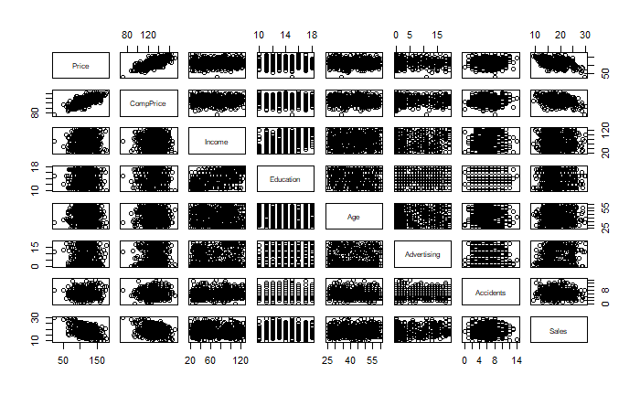

```r
# Scatterplot matrix
pairs(cardata[,c(1:7,10)])
```

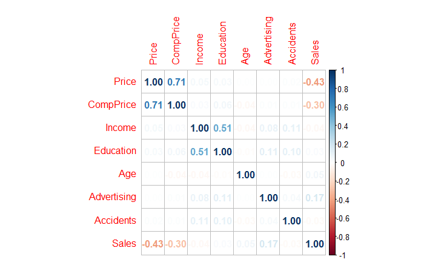

```r
# Correlation matrix
CorMatrix = cor(cardata[,c(1:7,10)], method = "pearson")

library(corrplot)
corrplot(CorMatrix, method = "number")
```

Notable positive correlation between price and competitor price, and median income and education level of the location Notable negative correlation between price and sales at each location

```r
# Size of the dataset

dim(cardata)
```

```
[1] 500  11
```

10 regression variables and 1 response variable (Sales)

# 1. Stepwise selection

## 1.1 Using AIC criteria

```r
#using stepAIC function in Mass
library(MASS)
#MLR - Null Model (Model with only intercept)
nullModel=lm(Sales~1, data=cardata.train)

#MLR - First order full model
fullModel=lm(Sales~Price+CompPrice+Income+Education+Age+Advertising+Accidents+Urban+US+ShelveLoc, data=cardata.train)
```

### 1.1.1 Forward selection based on AIC

```r
#Automatic Forward selection based on AIC
stepAIC(nullModel,scope=list(lower=nullModel,upper=fullModel),direction="forward")
```

```
Start:  AIC=1139.58
Sales ~ 1

              Df Sum of Sq    RSS     AIC
+ ShelveLoc    2    4840.5 2032.8  656.28
+ Price        1    1181.2 5692.1 1066.15
+ CompPrice    1     587.0 6286.3 1105.87
+ Advertising  1     290.2 6583.1 1124.32
<none>                     6873.3 1139.58
+ US           1      24.5 6848.8 1140.15
+ Urban        1      22.9 6850.4 1140.24
+ Education    1      20.8 6852.6 1140.36
+ Income       1      11.7 6861.7 1140.90
+ Age          1       3.7 6869.6 1141.36
+ Accidents    1       0.0 6873.3 1141.57

Step:  AIC=656.28
Sales ~ ShelveLoc

              Df Sum of Sq     RSS    AIC
+ Price        1   1200.77  832.01 300.95
+ CompPrice    1    604.48 1428.30 517.11
+ Advertising  1    149.00 1883.79 627.83
+ Education    1     17.23 2015.55 654.87
<none>                     2032.78 656.28
+ Accidents    1      5.73 2027.05 657.15
+ US           1      5.67 2027.12 657.16
+ Age          1      5.18 2027.60 657.26
+ Income       1      2.39 2030.40 657.81
+ Urban        1      1.18 2031.61 658.05

Step:  AIC=300.95
Sales ~ ShelveLoc + Price

              Df Sum of Sq    RSS    AIC
+ Advertising  1   157.804 674.21 218.83
+ Education    1    26.702 805.31 289.90
+ Income       1     6.103 825.91 300.01
+ Accidents    1     4.255 827.76 300.90
<none>                     832.01 300.95
```

[output cut: 37 more lines]

```
+ US         1   0.34247 656.60 214.24
+ Income     1   0.21969 656.72 214.32
+ CompPrice  1   0.02817 656.91 214.44

Call:
lm(formula = Sales ~ ShelveLoc + Price + Advertising + Education +
    Age, data = cardata.train)

Coefficients:
    (Intercept)    ShelveLocGood  ShelveLocMedium
       20.88779          9.12557          3.02975
          Price      Advertising        Education
       -0.07617          0.09659          0.07811
            Age
        0.01026
```

Forward selection (AIC): Sales ~ ShelveLoc + Price + Advertising + Education + Age

### 1.1.2 Backward selection based on AIC

```r
#Automatic Backward elimination based on AIC
stepAIC(fullModel,scope=list(lower=nullModel,upper=fullModel),direction="backward")
```

```
Start:  AIC=220.82
Sales ~ Price + CompPrice + Income + Education + Age + Advertising +
    Accidents + Urban + US + ShelveLoc

              Df Sum of Sq    RSS     AIC
- CompPrice    1       0.0  654.3  218.83
- US           1       0.3  654.5  218.98
- Income       1       0.4  654.7  219.06
- Urban        1       0.6  654.9  219.19
- Accidents    1       1.4  655.7  219.67
<none>                      654.3  220.82
- Age          1       4.2  658.5  221.38
- Education    1      10.9  665.2  225.44
- Advertising  1     143.3  797.6  298.05
- Price        1     586.9 1241.2  474.94
- ShelveLoc    2    4647.9 5302.2 1053.76

Step:  AIC=218.83
Sales ~ Price + Income + Education + Age + Advertising + Accidents +
    Urban + US + ShelveLoc

              Df Sum of Sq    RSS     AIC
- US           1       0.3  654.5  216.99
- Income       1       0.4  654.7  217.06
- Urban        1       0.6  654.9  217.20
- Accidents    1       1.4  655.7  217.69
<none>                      654.3  218.83
- Age          1       4.2  658.5  219.40
- Education    1      10.9  665.2  223.46
- Advertising  1     143.3  797.6  296.05
- Price        1    1204.8 1859.0  634.54
- ShelveLoc    2    4647.9 5302.2 1051.77

Step:  AIC=216.99
Sales ~ Price + Income + Education + Age + Advertising + Accidents +
    Urban + ShelveLoc

              Df Sum of Sq    RSS     AIC
- Income       1       0.4  654.9  215.21
- Urban        1       0.6  655.1  215.34
```

[output cut: 41 more lines]

```
- Advertising  1     145.0  802.0  290.25
- Price        1    1213.3 1870.2  628.94
- ShelveLoc    2    4720.9 5377.8 1049.43

Call:
lm(formula = Sales ~ Price + Education + Age + Advertising +
    ShelveLoc, data = cardata.train)

Coefficients:
    (Intercept)            Price        Education
       20.88779         -0.07617          0.07811
            Age      Advertising    ShelveLocGood
        0.01026          0.09659          9.12557
ShelveLocMedium
        3.02975
```

Backward selection (AIC): Sales ~ Price + Education + Age + Advertising + ShelveLoc

### 1.3 Bi-directional selection based on AIC

```r
#Automatic bi-directional selection based on AIC
stepAIC(fullModel,scope=list(lower=nullModel,upper=fullModel),direction="both")
```

```
Start:  AIC=220.82
Sales ~ Price + CompPrice + Income + Education + Age + Advertising +
    Accidents + Urban + US + ShelveLoc

              Df Sum of Sq    RSS     AIC
- CompPrice    1       0.0  654.3  218.83
- US           1       0.3  654.5  218.98
- Income       1       0.4  654.7  219.06
- Urban        1       0.6  654.9  219.19
- Accidents    1       1.4  655.7  219.67
<none>                      654.3  220.82
- Age          1       4.2  658.5  221.38
- Education    1      10.9  665.2  225.44
- Advertising  1     143.3  797.6  298.05
- Price        1     586.9 1241.2  474.94
- ShelveLoc    2    4647.9 5302.2 1053.76

Step:  AIC=218.83
Sales ~ Price + Income + Education + Age + Advertising + Accidents +
    Urban + US + ShelveLoc

              Df Sum of Sq    RSS     AIC
- US           1       0.3  654.5  216.99
- Income       1       0.4  654.7  217.06
- Urban        1       0.6  654.9  217.20
- Accidents    1       1.4  655.7  217.69
<none>                      654.3  218.83
- Age          1       4.2  658.5  219.40
+ CompPrice    1       0.0  654.3  220.82
- Education    1      10.9  665.2  223.46
- Advertising  1     143.3  797.6  296.05
- Price        1    1204.8 1859.0  634.54
- ShelveLoc    2    4647.9 5302.2 1051.77

Step:  AIC=216.99
Sales ~ Price + Income + Education + Age + Advertising + Accidents +
    Urban + ShelveLoc

              Df Sum of Sq    RSS     AIC
- Income       1       0.4  654.9  215.21
```

[output cut: 54 more lines]

```
+ CompPrice    1       0.0  656.9  214.44
- Education    1      13.4  670.4  218.55
- Advertising  1     145.0  802.0  290.25
- Price        1    1213.3 1870.2  628.94
- ShelveLoc    2    4720.9 5377.8 1049.43

Call:
lm(formula = Sales ~ Price + Education + Age + Advertising +
    ShelveLoc, data = cardata.train)

Coefficients:
    (Intercept)            Price        Education              Age      Advertising    ShelveLocGood
       20.88779         -0.07617          0.07811          0.01026          0.09659          9.12557
ShelveLocMedium
        3.02975
```

Bi-direction selection (AIC): Sales ~ Price + Education + Age + Advertising +ShelveLoc

#### Conslusion: using all three stepwise methods (foward, backward, bi-directional) based on AIC, we have Price, Education, Age, Advertising, ShelveLoc as the chosen predictors.

## 1.2 Using BIC criteria

### 1.2.1 Forward selection based on BIC

```r
#Automatic Forward selection based on BIC
stepAIC(nullModel,scope=list(lower=nullModel,upper=fullModel),direction="forward",k=log(nrow(cardata.train)))
```

```
Start:  AIC=1143.57
Sales ~ 1

              Df Sum of Sq    RSS     AIC
+ ShelveLoc    2    4840.5 2032.8  668.25
+ Price        1    1181.2 5692.1 1074.13
+ CompPrice    1     587.0 6286.3 1113.85
+ Advertising  1     290.2 6583.1 1132.30
<none>                     6873.3 1143.57
+ US           1      24.5 6848.8 1148.13
+ Urban        1      22.9 6850.4 1148.22
+ Education    1      20.8 6852.6 1148.35
+ Income       1      11.7 6861.7 1148.88
+ Age          1       3.7 6869.6 1149.34
+ Accidents    1       0.0 6873.3 1149.56

Step:  AIC=668.25
Sales ~ ShelveLoc

              Df Sum of Sq     RSS    AIC
+ Price        1   1200.77  832.01 316.92
+ CompPrice    1    604.48 1428.30 533.08
+ Advertising  1    149.00 1883.79 643.80
<none>                     2032.78 668.25
+ Education    1     17.23 2015.55 670.84
+ Accidents    1      5.73 2027.05 673.12
+ US           1      5.67 2027.12 673.13
+ Age          1      5.18 2027.60 673.22
+ Income       1      2.39 2030.40 673.78
+ Urban        1      1.18 2031.61 674.01

Step:  AIC=316.92
Sales ~ ShelveLoc + Price

              Df Sum of Sq    RSS    AIC
+ Advertising  1   157.804 674.21 238.79
+ Education    1    26.702 805.31 309.86
<none>                     832.01 316.92
+ Income       1     6.103 825.91 319.96
+ Accidents    1     4.255 827.76 320.86
```

[output cut: 22 more lines]

```
<none>                   661.04 236.89
+ Age        1    4.0983 656.94 240.39
+ Accidents  1    1.3112 659.73 242.09
+ Urban      1    0.5723 660.47 242.53
+ US         1    0.4127 660.63 242.63
+ Income     1    0.2549 660.79 242.73
+ CompPrice  1    0.0382 661.00 242.86

Call:
lm(formula = Sales ~ ShelveLoc + Price + Advertising + Education,
    data = cardata.train)

Coefficients:
    (Intercept)    ShelveLocGood  ShelveLocMedium            Price      Advertising        Education
       21.34246          9.12328          3.02609         -0.07624          0.09632          0.07732
```

Forward selection (BIC): Sales ~ ShelveLoc + Price + Advertising + Education

### 1.2.2 Backward selection based on BIC

```r
#Automatic Backward elimination based on BIC
stepAIC(fullModel,scope=list(lower=nullModel,upper=fullModel),direction="backward",k=log(nrow(cardata.train)))
```

```
Start:  AIC=268.72
Sales ~ Price + CompPrice + Income + Education + Age + Advertising +
    Accidents + Urban + US + ShelveLoc

              Df Sum of Sq    RSS     AIC
- CompPrice    1       0.0  654.3  262.74
- US           1       0.3  654.5  262.89
- Income       1       0.4  654.7  262.96
- Urban        1       0.6  654.9  263.09
- Accidents    1       1.4  655.7  263.57
- Age          1       4.2  658.5  265.29
<none>                      654.3  268.72
- Education    1      10.9  665.2  269.35
- Advertising  1     143.3  797.6  341.96
- Price        1     586.9 1241.2  518.85
- ShelveLoc    2    4647.9 5302.2 1093.68

Step:  AIC=262.74
Sales ~ Price + Income + Education + Age + Advertising + Accidents +
    Urban + US + ShelveLoc

              Df Sum of Sq    RSS     AIC
- US           1       0.3  654.5  256.90
- Income       1       0.4  654.7  256.98
- Urban        1       0.6  654.9  257.11
- Accidents    1       1.4  655.7  257.60
- Age          1       4.2  658.5  259.31
<none>                      654.3  262.74
- Education    1      10.9  665.2  263.37
- Advertising  1     143.3  797.6  335.97
- Price        1    1204.8 1859.0  674.46
- ShelveLoc    2    4647.9 5302.2 1087.69

Step:  AIC=256.9
Sales ~ Price + Income + Education + Age + Advertising + Accidents +
    Urban + ShelveLoc

              Df Sum of Sq    RSS     AIC
- Income       1       0.4  654.9  251.13
- Urban        1       0.6  655.1  251.27
```

[output cut: 47 more lines]

```

              Df Sum of Sq    RSS     AIC
<none>                      661.0  236.89
- Education    1      13.2  674.2  238.79
- Advertising  1     144.3  805.3  309.86
- Price        1    1215.7 1876.8  648.30
- ShelveLoc    2    4719.8 5380.9 1063.62

Call:
lm(formula = Sales ~ Price + Education + Advertising + ShelveLoc,
    data = cardata.train)

Coefficients:
    (Intercept)            Price        Education      Advertising    ShelveLocGood  ShelveLocMedium
       21.34246         -0.07624          0.07732          0.09632          9.12328          3.02609
```

Backward selection (BIC): Sales ~ Price + Education + Advertising + ShelveLoc

### 1.2.3 Bi-directional selection based on BIC

```r
#Automatic bi-directional selection based on BIC
stepAIC(fullModel,scope=list(lower=nullModel,upper=fullModel),direction="both",k=log(nrow(cardata.train)))
```

```
Start:  AIC=268.72
Sales ~ Price + CompPrice + Income + Education + Age + Advertising +
    Accidents + Urban + US + ShelveLoc

              Df Sum of Sq    RSS     AIC
- CompPrice    1       0.0  654.3  262.74
- US           1       0.3  654.5  262.89
- Income       1       0.4  654.7  262.96
- Urban        1       0.6  654.9  263.09
- Accidents    1       1.4  655.7  263.57
- Age          1       4.2  658.5  265.29
<none>                      654.3  268.72
- Education    1      10.9  665.2  269.35
- Advertising  1     143.3  797.6  341.96
- Price        1     586.9 1241.2  518.85
- ShelveLoc    2    4647.9 5302.2 1093.68

Step:  AIC=262.74
Sales ~ Price + Income + Education + Age + Advertising + Accidents +
    Urban + US + ShelveLoc

              Df Sum of Sq    RSS     AIC
- US           1       0.3  654.5  256.90
- Income       1       0.4  654.7  256.98
- Urban        1       0.6  654.9  257.11
- Accidents    1       1.4  655.7  257.60
- Age          1       4.2  658.5  259.31
<none>                      654.3  262.74
- Education    1      10.9  665.2  263.37
+ CompPrice    1       0.0  654.3  268.72
- Advertising  1     143.3  797.6  335.97
- Price        1    1204.8 1859.0  674.46
- ShelveLoc    2    4647.9 5302.2 1087.69

Step:  AIC=256.9
Sales ~ Price + Income + Education + Age + Advertising + Accidents +
    Urban + ShelveLoc

              Df Sum of Sq    RSS     AIC
- Income       1       0.4  654.9  251.13
```

[output cut: 68 more lines]

```
+ Urban        1       0.6  660.5  242.53
+ US           1       0.4  660.6  242.63
+ Income       1       0.3  660.8  242.73
+ CompPrice    1       0.0  661.0  242.86
- Advertising  1     144.3  805.3  309.86
- Price        1    1215.7 1876.8  648.30
- ShelveLoc    2    4719.8 5380.9 1063.62

Call:
lm(formula = Sales ~ Price + Education + Advertising + ShelveLoc,
    data = cardata.train)

Coefficients:
    (Intercept)            Price        Education      Advertising    ShelveLocGood  ShelveLocMedium
       21.34246         -0.07624          0.07732          0.09632          9.12328          3.02609
```

Bi-direction selection (BIC): Sales ~ Price + Education + Advertising + ShelveLoc

#### Conclusion: using all three stepwise methods (foward, backward, bi-directional) based on BIC, we have Price, Education, Advertising, ShelveLoc as the chosen predictors.

### 1.3. Testing the selected models

### 1.3.1 Fitting MLR Model using 5 predictors selected based on AIC

```r
#Fitted model for selected predictors (from AIC)
selectedModel=lm(Sales~Price+Education+Age+Advertising+ShelveLoc, data=cardata.train)
summary(selectedModel)
```

```
Call:
lm(formula = Sales ~ Price + Education + Age + Advertising +
    ShelveLoc, data = cardata.train)

Residuals:
    Min      1Q  Median      3Q     Max
-4.6614 -0.7751  0.0113  0.8246  3.8231

Coefficients:
                 Estimate Std. Error t value Pr(>|t|)
(Intercept)     20.887786   0.592176  35.273  < 2e-16 ***
Price           -0.076174   0.002827 -26.941  < 2e-16 ***
Education        0.078110   0.027554   2.835  0.00482 **
Age              0.010255   0.006549   1.566  0.11820
Advertising      0.096586   0.010369   9.315  < 2e-16 ***
ShelveLocGood    9.125573   0.180992  50.420  < 2e-16 ***
ShelveLocMedium  3.029749   0.166392  18.209  < 2e-16 ***
---
Signif. codes:  0 ‘***’ 0.001 ‘**’ 0.01 ‘*’ 0.05 ‘.’ 0.1 ‘ ’ 1

Residual standard error: 1.293 on 393 degrees of freedom
Multiple R-squared:  0.9044,    Adjusted R-squared:  0.903
F-statistic: 619.8 on 6 and 393 DF,  p-value: < 2.2e-16
```

MLR model (stepwise selection - AIC):

```r
#Fitted model for selected predictors (from BIC)
selectedModel2=lm(Sales~Price+Education+Advertising+ShelveLoc, data=cardata.train)
summary(selectedModel2)
```

```
Call:
lm(formula = Sales ~ Price + Education + Advertising + ShelveLoc,
    data = cardata.train)

Residuals:
    Min      1Q  Median      3Q     Max
-4.8186 -0.7787 -0.0189  0.7999  3.8882

Coefficients:
                 Estimate Std. Error t value Pr(>|t|)
(Intercept)     21.342464   0.517042  41.278  < 2e-16 ***
Price           -0.076242   0.002832 -26.919  < 2e-16 ***
Education        0.077323   0.027601   2.801  0.00534 **
Advertising      0.096316   0.010387   9.273  < 2e-16 ***
ShelveLocGood    9.123282   0.181319  50.316  < 2e-16 ***
ShelveLocMedium  3.026095   0.166681  18.155  < 2e-16 ***
---
Signif. codes:  0 ‘***’ 0.001 ‘**’ 0.01 ‘*’ 0.05 ‘.’ 0.1 ‘ ’ 1

Residual standard error: 1.295 on 394 degrees of freedom
Multiple R-squared:  0.9038,    Adjusted R-squared:  0.9026
F-statistic: 740.5 on 5 and 394 DF,  p-value: < 2.2e-16
```

MLR model (stepwise - BIC):

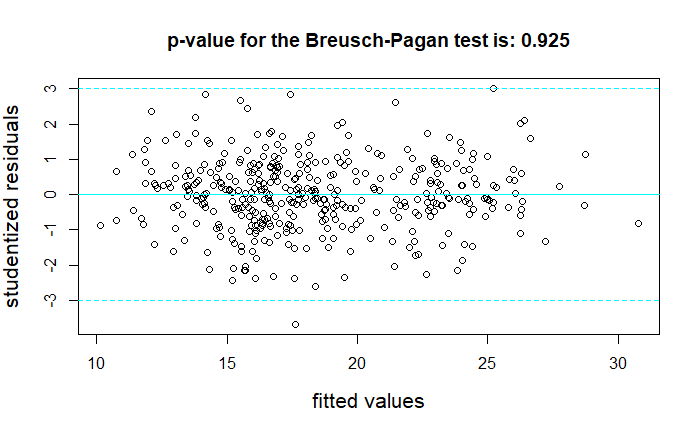

```r
#diagnostics for selected model using AIC
library(MASS); library(lmtest)
stud.residuals = studres(selectedModel)
fitted.values = selectedModel$fitted.values

plot(x=fitted.values, y=stud.residuals, xlab="fitted values", ylab="studentized residuals", cex.lab=1.3, main=paste0("p-value for the Breusch-Pagan test is: ", round(bptest(selectedModel)$p.value, 3)))
abline(h=0,col="turquoise1");abline(h=-3,col="turquoise1",lty=2);abline(h=3,col="turquoise1",lty=2)
```

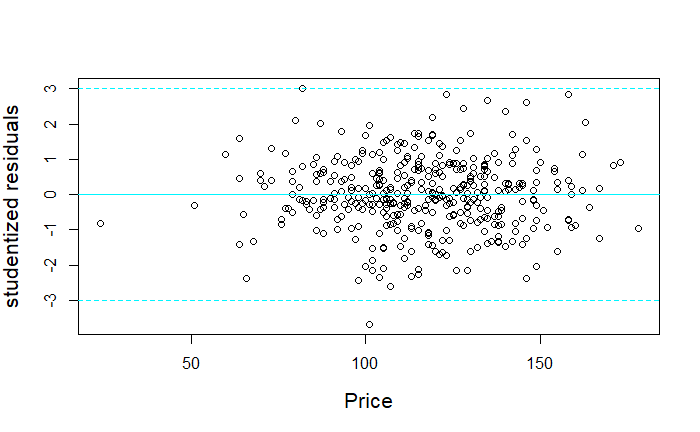

```r
plot(x=cardata.train$Price,y=stud.residuals,xlab="Price",ylab="studentized residuals",main="",cex.lab=1.3)
abline(h=0,col="turquoise1");abline(h=-3,col="turquoise1",lty=2);abline(h=3,col="turquoise1",lty=2)
```

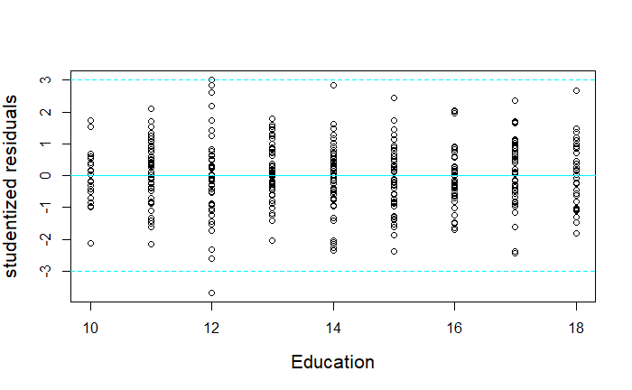

```r
plot(x=cardata.train$Education,y=stud.residuals,xlab="Education",ylab="studentized residuals",main="",cex.lab=1.3)
abline(h=0,col="turquoise1");abline(h=-3,col="turquoise1",lty=2);abline(h=3,col="turquoise1",lty=2)
```

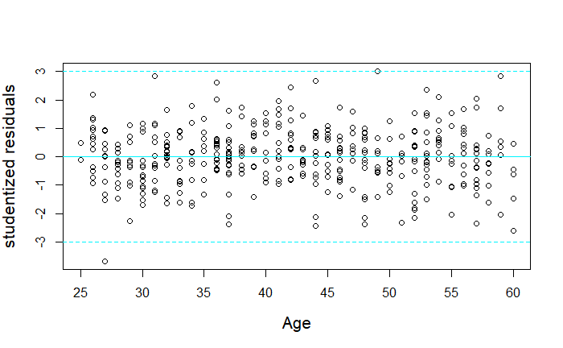

```r
plot(x=cardata.train$Age,y=stud.residuals,xlab="Age",ylab="studentized residuals",main="",cex.lab=1.3)
abline(h=0,col="turquoise1");abline(h=-3,col="turquoise1",lty=2);abline(h=3,col="turquoise1",lty=2)
```

```r
plot(x=cardata.train$Advertising,y=stud.residuals,xlab="Advertising",ylab="studentized residuals",main="",cex.lab=1.3)
abline(h=0,col="turquoise1");abline(h=-3,col="turquoise1",lty=2);abline(h=3,col="turquoise1",lty=2)
```

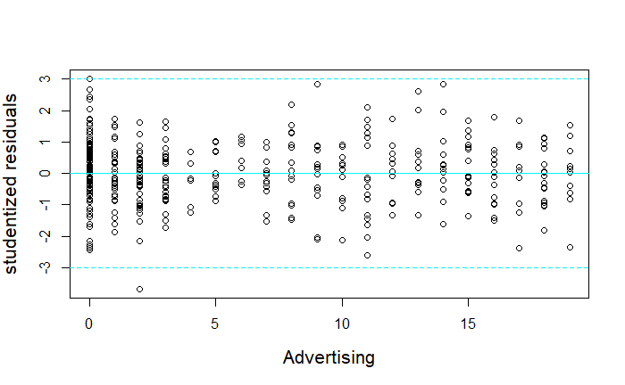

```r
par(mfrow=c(1,1))
```

```r
library(car)
#Normal QQ plot
qqnorm(stud.residuals,main=paste0("p-value for the Shapiro-Wilk test is: ", round(shapiro.test(stud.residuals)$p.value,3)),cex.lab=1.5)
abline(a=0,b=1,col="turquoise1")
```

```r
#Vif values
vif(selectedModel)
```

```
                GVIF Df GVIF^(1/(2*Df))
Price       1.001995  1        1.000997
Education   1.017052  1        1.008490
Age         1.001136  1        1.000568
Advertising 1.030111  1        1.014944
ShelveLoc   1.014955  2        1.003718
```

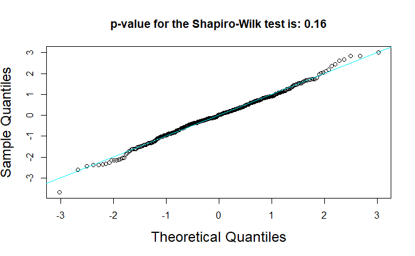

```r
#outliers, leverage and cook's distance
par(mfrow=c(3,1))
```

```r
plot(cardata.train$Sales,fitted.values,xlab="Observed response",ylab="Fitted response")
abline(a=0,b=1,col=2)
```

```r
plot(hatvalues(selectedModel),type="h",ylab="Leverage",cex.lab=1.5)
n=nrow(cardata.train)
p=length(coefficients(selectedModel))
cutLev=2*p/n
abline(h=cutLev,col="turquoise1")
```

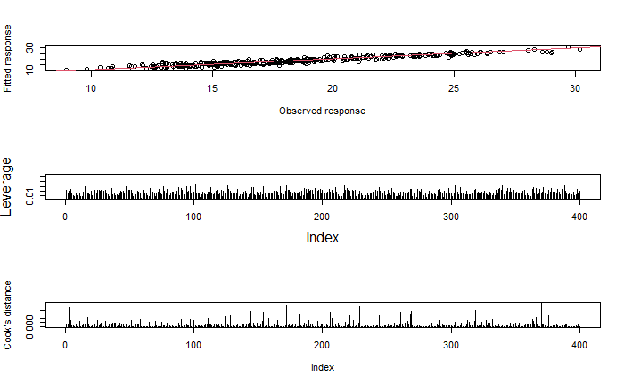

```r
plot(cooks.distance(selectedModel),ylab="Cook's distance",type="h")
abline(h=1,col="turquoise1")
```

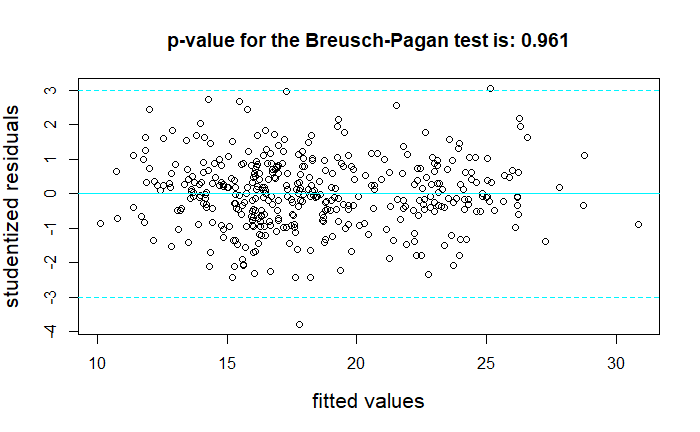

```r
#diagnostics for selected model using BIC
stud.residuals2 = studres(selectedModel2)
fitted.values2 = selectedModel2$fitted.values

plot(x=fitted.values2, y=stud.residuals2, xlab="fitted values", ylab="studentized residuals", cex.lab=1.3, main=paste0("p-value for the Breusch-Pagan test is: ", round(bptest(selectedModel2)$p.value, 3)))
abline(h=0,col="turquoise1");abline(h=-3,col="turquoise1",lty=2);abline(h=3,col="turquoise1",lty=2)
```

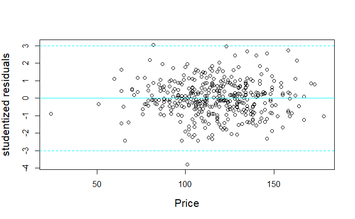

```r
plot(x=cardata.train$Price,y=stud.residuals2,xlab="Price",ylab="studentized residuals",main="",cex.lab=1.3)
abline(h=0,col="turquoise1");abline(h=-3,col="turquoise1",lty=2);abline(h=3,col="turquoise1",lty=2)
```

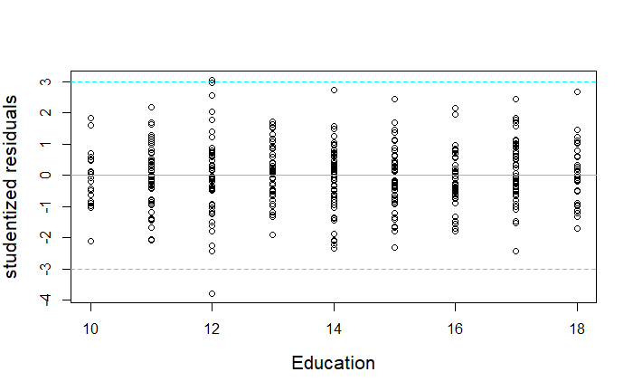

```r
plot(x=cardata.train$Education,y=stud.residuals2,xlab="Education",ylab="studentized residuals",main="",cex.lab=1.3)
abline(h=0,col="turquoise1");abline(h=-3,col="turquoise1",lty=2);abline(h=3,col="turquoise1",lty=2)
```

```r
plot(x=cardata.train$Advertising,y=stud.residuals2,xlab="Advertising",ylab="studentized residuals",main="",cex.lab=1.3)
abline(h=0,col="turquoise1");abline(h=-3,col="turquoise1",lty=2);abline(h=3,col="turquoise1",lty=2)
```

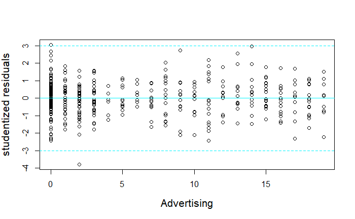

```r
## checking normality
par(mfrow=c(1,1))
```

```r
#Normal QQ plot
qqnorm(stud.residuals2,main=paste0("p-value for the Shapiro-Wilk test is: ", round(shapiro.test(stud.residuals2)$p.value,3)),cex.lab=1.5)
abline(a=0,b=1,col="turquoise1")
```

```r
#Vif values
vif(selectedModel2)
```

```
                GVIF Df GVIF^(1/(2*Df))
Price       1.001758  1        1.000879
Education   1.016714  1        1.008322
Advertising 1.029827  1        1.014804
ShelveLoc   1.014754  2        1.003668
```

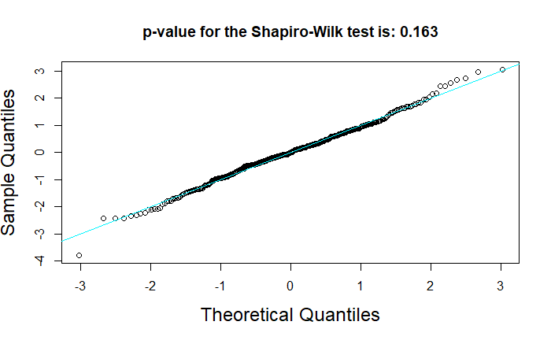

```r
#outliers, leverage and cook's distance
par(mfrow=c(3,1))
```

```r
plot(cardata.train$Sales,fitted.values2,xlab="Observed response",ylab="Fitted response")
abline(a=0,b=1,col=2)
```

```r
plot(hatvalues(selectedModel2),type="h",ylab="Leverage",cex.lab=1.5)
n=nrow(cardata.train)
p=length(coefficients(selectedModel2))
cutLev=2*p/n
abline(h=cutLev,col="turquoise1")
```

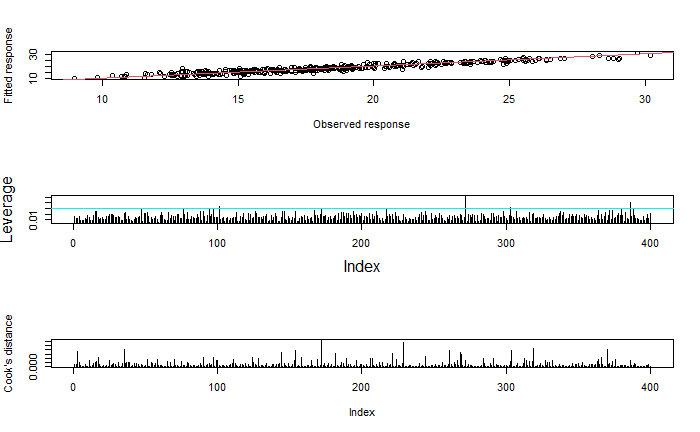

```r
plot(cooks.distance(selectedModel2),ylab="Cook's distance",type="h")
abline(h=1,col="turquoise1")
```

### 1.4. Comparing the selected models

```r
# RMSE
library(Metrics)
rmse(cardata.test$Sales,predict(selectedModel,cardata.test)) #AIC model
```

```
[1] 1.425752
```

```r
rmse(cardata.test$Sales,predict(selectedModel2,cardata.test)) #BIC model
```

```
[1] 1.439049
```

```r
# RSS
summary(selectedModel)$r.squared #AIC model
```

```
[1] 0.9044215
```

```r
summary(selectedModel2)$r.squared #BIC model
```

```
[1] 0.9038252
```

```r
# Adjusted RSS
summary(selectedModel)$adj.r.squared #AIC model
```

```
[1] 0.9029623
```

```r
summary(selectedModel2)$adj.r.squared #BIC model
```

```
[1] 0.9026048
```

```r
# means of residuals
mean(cardata.test$Sales-predict(selectedModel,cardata.test)) #AIC model
```

```
[1] 0.03013093
```

```r
mean(cardata.test$Sales-predict(selectedModel2,cardata.test)) #BIC model
```

```
[1] 0.02606654
```

```r
# means of absolute residuals
mae(cardata.test$Sales,predict(selectedModel,cardata.test)) #AIC model
```

```
[1] 1.154179
```

```r
mae(cardata.test$Sales,predict(selectedModel2,cardata.test)) #BIC model
```

```
[1] 1.179559
```

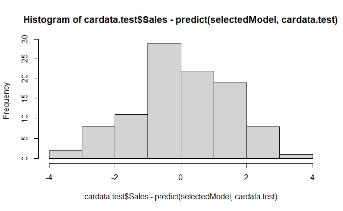

```r
# histogram of residuals
hist(cardata.test$Sales-predict(selectedModel,cardata.test)) #AIC model
```

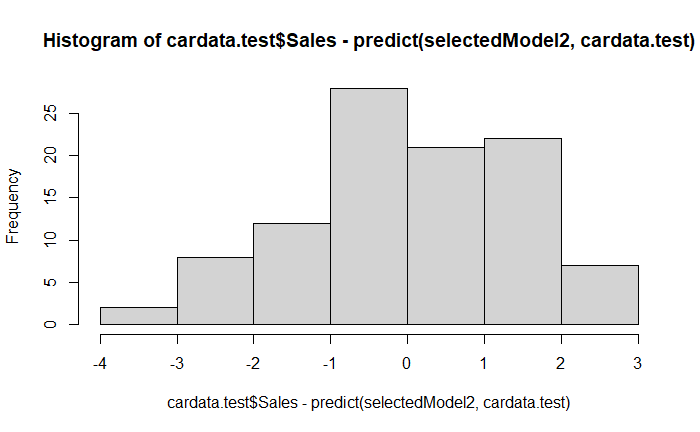

```r
hist(cardata.test$Sales-predict(selectedModel2,cardata.test)) #BIC model
```

```r
# correlations between of predicted and observed values
predicted=predict(selectedModel,newdata = cardata.test)
predicted2=predict(selectedModel2,newdata = cardata.test)
cor(cardata.test$Sales,predicted)
```

```
[1] 0.9380403
```

```r
cor(cardata.test$Sales,predicted2)
```

```
[1] 0.9367991
```

### 1.5. using p value

```r
library(olsrr)
ols_step_forward_p(fullModel)
```

```
                              Selection Summary
------------------------------------------------------------------------------
        Variable                     Adj.
Step      Entered      R-Square    R-Square      C(p)         AIC        RMSE
------------------------------------------------------------------------------
   1    ShelveLoc        0.7042      0.7028    809.4995    1793.4297    2.2628
   2    Price            0.8790      0.8780     99.4065    1438.1034    1.4495
   3    Advertising      0.9019      0.9009      7.8244    1355.9802    1.3065
   4    Education        0.9038      0.9026      2.0156    1350.0907    1.2953
   5    Age              0.9044      0.9030      1.5852    1349.6030    1.2929
------------------------------------------------------------------------------
```

```r
library(olsrr)
ols_step_backward_p(fullModel)
```

```
                           Elimination Summary
--------------------------------------------------------------------------
        Variable                   Adj.
Step     Removed     R-Square    R-Square     C(p)        AIC        RMSE
--------------------------------------------------------------------------
   1    CompPrice      0.9048      0.9024    8.0092    1355.9817    1.2969
   2    US             0.9048      0.9026    6.1613    1354.1384    1.2955
   3    Income         0.9047      0.9028    4.3736    1352.3571    1.2942
   4    Urban          0.9046      0.9029    2.6922    1350.6851    1.2931
   5    Accidents      0.9044       0.903    1.5852    1349.6030    1.2929
--------------------------------------------------------------------------
```

```r
library(olsrr)
ols_step_both_p(fullModel)
```

```
                                Stepwise Selection Summary
------------------------------------------------------------------------------------------
                        Added/                   Adj.
Step     Variable      Removed     R-Square    R-Square      C(p)         AIC        RMSE
------------------------------------------------------------------------------------------
   1     ShelveLoc     addition       0.704       0.703    809.4990    1793.4297    2.2628
   2       Price       addition       0.879       0.878     99.4070    1438.1034    1.4495
   3    Advertising    addition       0.902       0.901      7.8240    1355.9802    1.3065
   4     Education     addition       0.904       0.903      2.0160    1350.0907    1.2953
------------------------------------------------------------------------------------------
```

# 2. Best subset selection

```r
# First order full model

library(leaps)
fullmodel = regsubsets(Sales~., data = cardata, nvmax = 11)
summary(fullmodel)
```

```
Subset selection object
Call: regsubsets.formula(Sales ~ ., data = cardata, nvmax = 11)
11 Variables  (and intercept)
                Forced in Forced out
Price               FALSE      FALSE
CompPrice           FALSE      FALSE
Income              FALSE      FALSE
Education           FALSE      FALSE
Age                 FALSE      FALSE
Advertising         FALSE      FALSE
Accidents           FALSE      FALSE
Urban1              FALSE      FALSE
US1                 FALSE      FALSE
ShelveLocGood       FALSE      FALSE
ShelveLocMedium     FALSE      FALSE
1 subsets of each size up to 11
Selection Algorithm: exhaustive
          Price CompPrice Income Education Age Advertising Accidents Urban1 US1 ShelveLocGood ShelveLocMedium
1  ( 1 )  " "   " "       " "    " "       " " " "         " "       " "    " " "*"           " "
2  ( 1 )  "*"   " "       " "    " "       " " " "         " "       " "    " " "*"           " "
3  ( 1 )  "*"   " "       " "    " "       " " " "         " "       " "    " " "*"           "*"
4  ( 1 )  "*"   " "       " "    " "       " " "*"         " "       " "    " " "*"           "*"
5  ( 1 )  "*"   " "       " "    "*"       " " "*"         " "       " "    " " "*"           "*"
6  ( 1 )  "*"   " "       " "    "*"       "*" "*"         " "       " "    " " "*"           "*"
7  ( 1 )  "*"   " "       "*"    "*"       "*" "*"         " "       " "    " " "*"           "*"
8  ( 1 )  "*"   " "       "*"    "*"       "*" "*"         "*"       " "    " " "*"           "*"
9  ( 1 )  "*"   " "       "*"    "*"       "*" "*"         "*"       " "    "*" "*"           "*"
10  ( 1 ) "*"   "*"       "*"    "*"       "*" "*"         "*"       " "    "*" "*"           "*"
11  ( 1 ) "*"   "*"       "*"    "*"       "*" "*"         "*"       "*"    "*" "*"           "*"
```

```r
names(summary(fullmodel))
```

```
[1] "which"  "rsq"    "rss"    "adjr2"  "cp"     "bic"    "outmat" "obj"
```

```r
# Performance indicators

Performance = data.frame(cbind(
  Cp = summary(fullmodel)$cp,
  r2 = summary(fullmodel)$rsq,
  Adj_r2 = summary(fullmodel)$adjr2,
  BIC = summary(fullmodel)$bic
))
```

```r
Performance
```

| Cp | r2 | Adj_r2 | BIC |
| --- | --- | --- | --- |
| 1312.160943 | 0.6289244 | 0.6281793 | -483.2455 |
| 475.003204 | 0.8011386 | 0.8003383 | -788.9297 |
| 116.568528 | 0.8751079 | 0.8743526 | -1015.2943 |
| 13.328966 | 0.8967055 | 0.8958708 | -1104.0125 |
| 5.497369 | 0.8987232 | 0.8976981 | -1107.6611 |
| 2.792997 | 0.8996886 | 0.8984678 | -1106.2357 |
| 4.239967 | 0.8998021 | 0.8983765 | -1100.5871 |
| 6.047759 | 0.8998415 | 0.8982096 | -1094.5694 |
| 8.027600 | 0.8998457 | 0.8980061 | -1088.3754 |
| 10.008629 | 0.8998496 | 0.8978015 | -1082.1803 |

[output cut: 1 more lines]

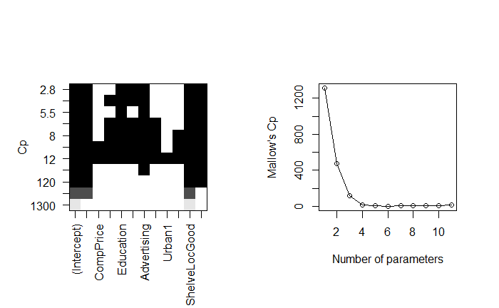

```r
# Mallow's Cp

par(mfrow=c(1,2))

plot(fullmodel, scale = "Cp")
plot(x = 1:11, y = summary(fullmodel)$cp, type = "o", xlab = "Number of parameters", ylab = "Mallow's Cp")
```

Mallow’s Cp = Price + Education + Age + Ads + ShelvingLocationGood + ShelvingLocationMed

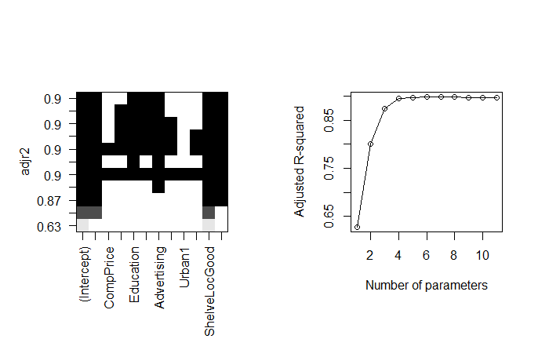

```r
#Adjusted R-squared

par(mfrow=c(1,2))

plot(fullmodel, scale = "adjr2")
plot(x = 1:11, y = summary(fullmodel)$adjr2, type = "o", xlab = "Number of parameters", ylab = "Adjusted R-squared")
```

Adj R-squared = Price + Education + Age + Ads + ShelvingLocationGood + ShelvingLocationMed

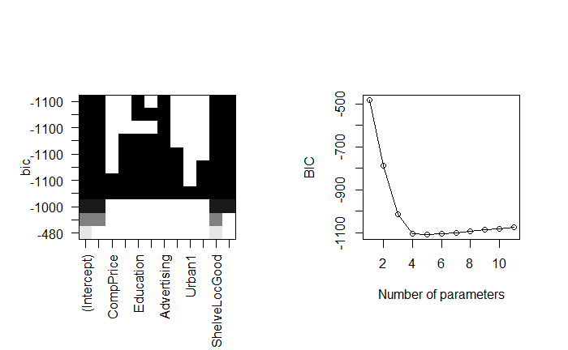

```r
# BIC

par(mfrow=c(1,2))

plot(fullmodel, scale = "bic")
plot(x = 1:11, y = summary(fullmodel)$bic, type = "o", xlab = "Number of parameters", ylab = "BIC")
```

BIC = Price + Education + Ads + ShelvingLocationGood + ShelvingLocationMed

#### We can potentially select models with 5 variables (BIC) or 6 variables (Adjusted R-sq, Mallow’s Cp)

```r
# Creating the best 5-variable model...
bestsubset5 = lm(Sales~Price + Education + Advertising + ShelveLoc, data = cardata)
summary(bestsubset5)
```

```
Call:
lm(formula = Sales ~ Price + Education + Advertising + ShelveLoc,
    data = cardata)

Residuals:
    Min      1Q  Median      3Q     Max
-4.8058 -0.7873 -0.0261  0.8921  3.8702

Coefficients:
                 Estimate Std. Error t value Pr(>|t|)
(Intercept)     21.354397   0.477105  44.758  < 2e-16 ***
Price           -0.076035   0.002599 -29.251  < 2e-16 ***
Education        0.079609   0.025376   3.137  0.00181 **
Advertising      0.093269   0.009483   9.836  < 2e-16 ***
ShelveLocGood    9.084968   0.166438  54.585  < 2e-16 ***
ShelveLocMedium  2.959084   0.152698  19.379  < 2e-16 ***
---
Signif. codes:  0 ‘***’ 0.001 ‘**’ 0.01 ‘*’ 0.05 ‘.’ 0.1 ‘ ’ 1

Residual standard error: 1.325 on 494 degrees of freedom
Multiple R-squared:  0.8987,    Adjusted R-squared:  0.8977
F-statistic: 876.7 on 5 and 494 DF,  p-value: < 2.2e-16
```

```r
library(car)
vif(bestsubset5)
```

```
                GVIF Df GVIF^(1/(2*Df))
Price       1.001259  1        1.000629
Education   1.014998  1        1.007471
Advertising 1.017042  1        1.008485
ShelveLoc   1.004576  2        1.001142
```

Little to no multicollinearity

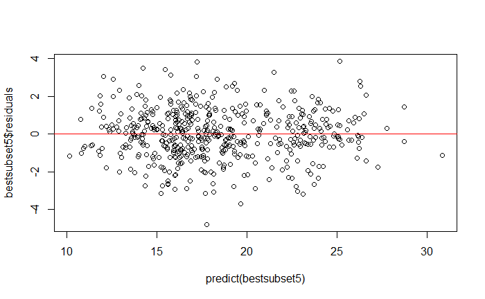

```r
{plot(x = predict(bestsubset5), y = bestsubset5$residuals)
abline(h = 0, col = "red")}
```

Randomly distributed residuals

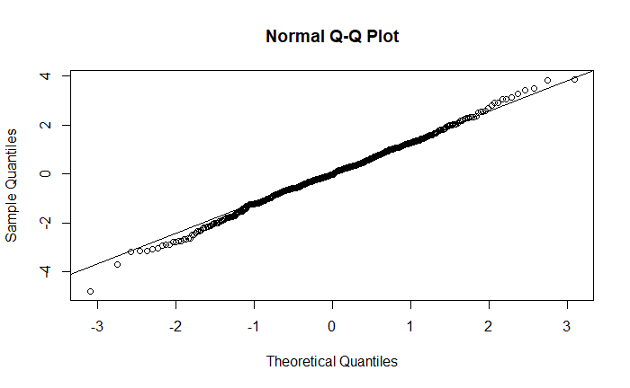

```r
{qqnorm(bestsubset5$residuals)
qqline(bestsubset5$residuals)}
```

```r
shapiro.test(bestsubset5$residuals)
```

```
    Shapiro-Wilk normality test

data:  bestsubset5$residuals
W = 0.99711, p-value = 0.5265
```

Normally distributed residuals with little deviation in the tail of the normal QQ plot, but the Shapiro-Wilk test indicates the normality of the best subset model.

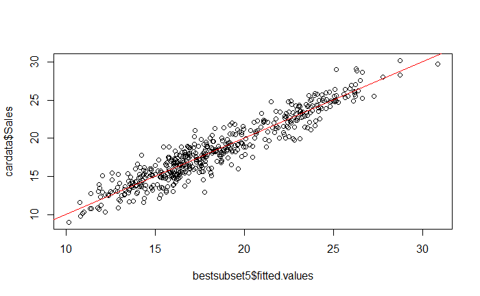

```r
{plot(x = bestsubset5$fitted.values, y = cardata$Sales)
abline(a = 0, b = 1, col = "red")}
```

Comparing the fitted value of the best subset model and the actual Sales value, there appears to be no outliers present

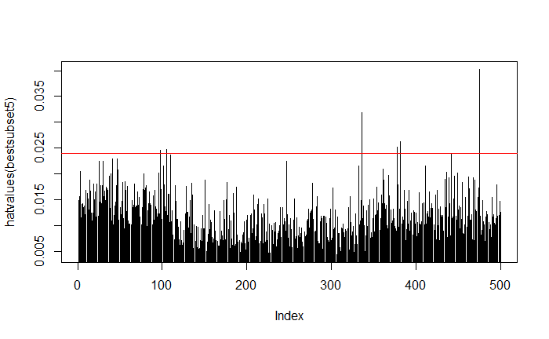

```r
n = nrow(cardata)
p = length(coefficients(bestsubset5))
cutlevel = 2*p/n

{plot(hatvalues(bestsubset5), type = 'h')
abline(h = cutlevel, col = "red")}
```

Two noticeable high leverage points present

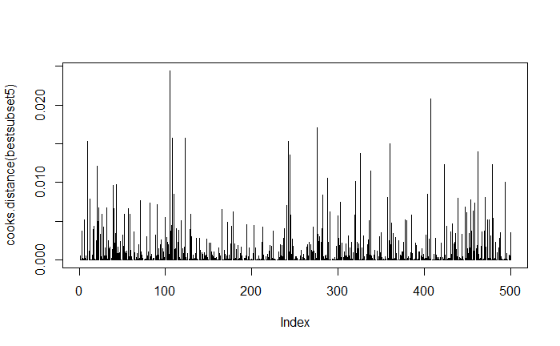

```r
{plot(cooks.distance(bestsubset5), type = "h")
abline(h = 1, col = "red")}
```

But none of the high leverage points are influential points according to the Cook’s Distance

```r
# Creating the best 6-variable model...
bestsubset6 = lm(Sales~Price + Education + Age + Advertising + ShelveLoc, data = cardata)
```

```r
library(car)
vif(bestsubset6)
```

```
                GVIF Df GVIF^(1/(2*Df))
Price       1.001267  1        1.000633
Education   1.015203  1        1.007573
Age         1.002768  1        1.001383
Advertising 1.017042  1        1.008485
ShelveLoc   1.007132  2        1.001778
```

Little to no multicollinearity

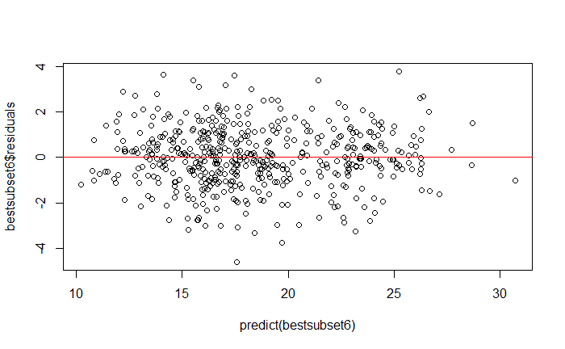

```r
{plot(x = predict(bestsubset6), y = bestsubset6$residuals)
abline(h = 0, col = "red")}
```

Randomly distributed residuals

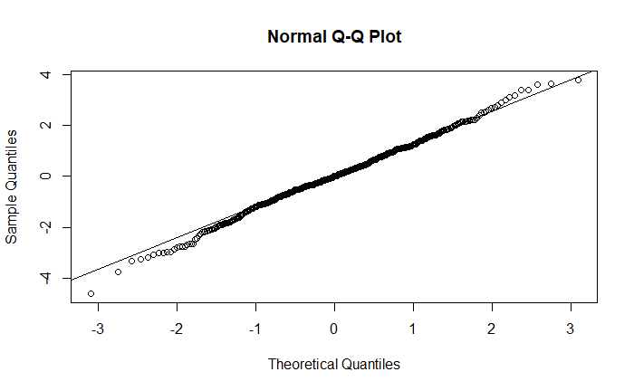

```r
{qqnorm(bestsubset6$residuals)
qqline(bestsubset6$residuals)}
```

```r
shapiro.test(bestsubset6$residuals)
```

```
    Shapiro-Wilk normality test

data:  bestsubset6$residuals
W = 0.99659, p-value = 0.3705
```

Normally distributed residuals with little deviation in the tail of the normal QQ plot, but the Shapiro-Wilk test indicates the normality of the best subset model.

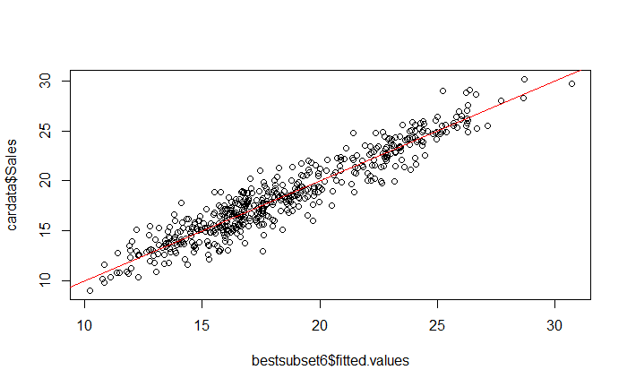

```r
{plot(x = bestsubset6$fitted.values, y = cardata$Sales)
abline(a = 0, b = 1, col = "red")}
```

Comparing the fitted value of the best subset model and the actual Sales value, there appears to be no outliers present

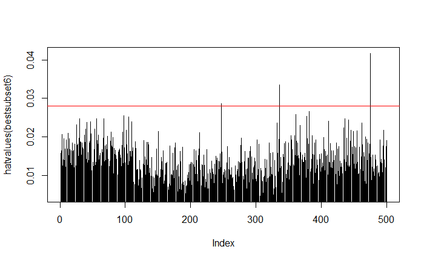

```r
n = nrow(cardata)
p = length(coefficients(bestsubset6))
cutlevel = 2*p/n

{plot(hatvalues(bestsubset6), type = 'h')
abline(h = cutlevel, col = "red")}
```

Two noticeable high leverage points present

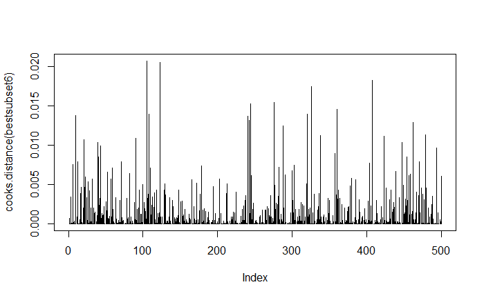

```r
{plot(cooks.distance(bestsubset6), type = "h")
abline(h = 1, col = "red")}
```

But none of the high leverage points are influential points according to the Cook’s Distance

#### Neither 5-variable model nor 6-variable model violate any assumptions for the linear regression analysis. In order to finalize the number of variables in the best subset model, we proceed to see which on of the two models yield better performance (lower error) under cross validation.

```r
# 400 data points in the training set
# 100 data points in the testing set

dim(cardata.train)
```

```
[1] 400  11
```

```r
dim(cardata.test)
```

```
[1] 100  11
```

Mallow’s Cp = 6 variable model

Adj R-squared = 6 variable model

BIC = 5 variable model

```r
# Names of the 5 variables

summary(fullmodel)$outmat[5, ]
```

```
          Price       CompPrice          Income       Education             Age     Advertising       Accidents
            "*"             " "             " "             "*"             " "             "*"             " "
         Urban1             US1   ShelveLocGood ShelveLocMedium
            " "             " "             "*"             "*"
```

The variables involved for 5-variable model are Price, Education, Advertising, and Shelving Location.

```r
# Names of the 6 variables

summary(fullmodel)$outmat[6, ]
```

```
          Price       CompPrice          Income       Education             Age     Advertising       Accidents
            "*"             " "             " "             "*"             "*"             "*"             " "
         Urban1             US1   ShelveLocGood ShelveLocMedium
            " "             " "             "*"             "*"
```

The variables involved for 6-variable model are Price, Education, Age, Advertising, and Shelve Location.

```r
# 5-variable model established from the training set

training.model5 = lm(Sales~Price + Education + Advertising + ShelveLoc, data = cardata.train)
summary(training.model5)
```

```
Call:
lm(formula = Sales ~ Price + Education + Advertising + ShelveLoc,
    data = cardata.train)

Residuals:
    Min      1Q  Median      3Q     Max
-4.8186 -0.7787 -0.0189  0.7999  3.8882

Coefficients:
                 Estimate Std. Error t value Pr(>|t|)
(Intercept)     21.342464   0.517042  41.278  < 2e-16 ***
Price           -0.076242   0.002832 -26.919  < 2e-16 ***
Education        0.077323   0.027601   2.801  0.00534 **
Advertising      0.096316   0.010387   9.273  < 2e-16 ***
ShelveLocGood    9.123282   0.181319  50.316  < 2e-16 ***
ShelveLocMedium  3.026095   0.166681  18.155  < 2e-16 ***
---
Signif. codes:  0 ‘***’ 0.001 ‘**’ 0.01 ‘*’ 0.05 ‘.’ 0.1 ‘ ’ 1

Residual standard error: 1.295 on 394 degrees of freedom
Multiple R-squared:  0.9038,    Adjusted R-squared:  0.9026
F-statistic: 740.5 on 5 and 394 DF,  p-value: < 2.2e-16
```

```r
# 6-variable model estalibhsed from the training set

training.model6 = lm(Sales~Price + Education + Age + Advertising + ShelveLoc, data = cardata.train)
summary(training.model6)
```

```
Call:
lm(formula = Sales ~ Price + Education + Age + Advertising +
    ShelveLoc, data = cardata.train)

Residuals:
    Min      1Q  Median      3Q     Max
-4.6614 -0.7751  0.0113  0.8246  3.8231

Coefficients:
                 Estimate Std. Error t value Pr(>|t|)
(Intercept)     20.887786   0.592176  35.273  < 2e-16 ***
Price           -0.076174   0.002827 -26.941  < 2e-16 ***
Education        0.078110   0.027554   2.835  0.00482 **
Age              0.010255   0.006549   1.566  0.11820
Advertising      0.096586   0.010369   9.315  < 2e-16 ***
ShelveLocGood    9.125573   0.180992  50.420  < 2e-16 ***
ShelveLocMedium  3.029749   0.166392  18.209  < 2e-16 ***
---
Signif. codes:  0 ‘***’ 0.001 ‘**’ 0.01 ‘*’ 0.05 ‘.’ 0.1 ‘ ’ 1

Residual standard error: 1.293 on 393 degrees of freedom
Multiple R-squared:  0.9044,    Adjusted R-squared:  0.903
F-statistic: 619.8 on 6 and 393 DF,  p-value: < 2.2e-16
```

```r
# MAE of 5-variable model

prediction5 = predict(training.model5, cardata.test)

MAE = function(actual, predicted){mean(abs(actual - predicted))}
MAE(cardata.test$Sales, prediction5)
```

```
[1] 1.179559
```

```r
# MAE of 6-variable model

prediction6 = predict(training.model6, cardata.test)

MAE = function(actual, predicted){mean(abs(actual - predicted))}
MAE(cardata.test$Sales, prediction6)
```

```
[1] 1.154179
```

6-variable model yields lower Mean Average Error (MAE) than 5-variable model. Therefore, according to the MAE, we are in favor of 6-variable model when using best subset approach.

```r
# RMSE and cor of 5-variable model

RMSE = function(actual, predicted){sqrt(mean((actual - predicted)^2))}
RMSE(cardata.test$Sales, prediction5)
```

```
[1] 1.439049
```

```r
cor(cardata.test$Sales ,prediction5)
```

```
[1] 0.9367991
```

```r
# RMSE and cor of 6-variable model

RMSE = function(actual, predicted){sqrt(mean((actual - predicted)^2))}
RMSE(cardata.test$Sales, prediction6)
```

```
[1] 1.425752
```

```r
cor(cardata.test$Sales ,prediction6)
```

```
[1] 0.9380403
```

6-variable model yields lower Root Mean Squared Error (RMSE) than 5-variable model. Therefore, according to the RMSE, we are in favor of 6-variable model when using best subset approach.

# 3. Regression tree

## 3.1 Create large regression tree (with depth of 30)

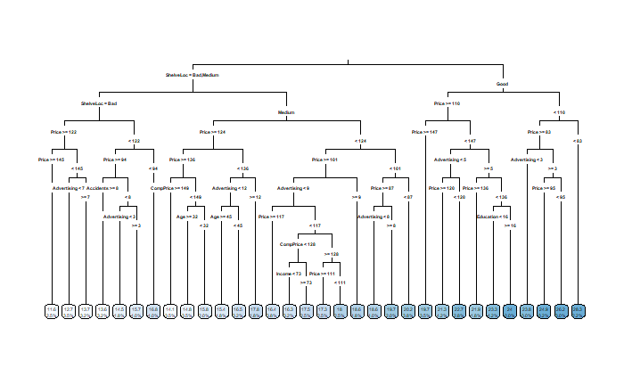

```r
#Install packages if they are not already installed
#install.packages('rpart.plot')
#install.packages('Metrics')
#install.packages('rpart')

#Loads library
library(rpart)
library(rpart.plot)
library(Metrics)

set.seed(50)

#Creates large regression tree model using testing set and prints the data
rt_model_full = rpart(Sales~., data=cardata.train, control=rpart.control(cp=0.0000001))
#jpeg(file="Project_fulltree.jpeg",width=6, height=4, units="in",res=400)
rpart.plot(rt_model_full, type=3, digits=3, fallen.leaves = T)
```

```r
#Creates a complexity plot
printcp(rt_model_full)
```

```
Regression tree:
rpart(formula = Sales ~ ., data = cardata.train, control = rpart.control(cp = 1e-07))

Variables actually used in tree construction:
[1] Accidents   Advertising Age         CompPrice   Education   Income      Price       ShelveLoc

Root node error: 6873.3/400 = 17.183

n= 400

           CP nsplit rel error  xerror     xstd
1  0.63519941      0  1.000000 1.00565 0.063671
2  0.06905058      1  0.364801 0.37016 0.024885
3  0.05461566      2  0.295750 0.32996 0.023269
4  0.04420340      3  0.241134 0.27786 0.019789
```

[output cut: 27 more lines]

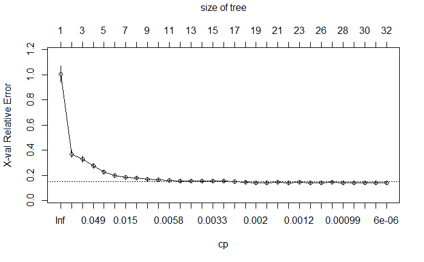

```r
#jpeg(file="Project_cp_vals.jpeg",width=6, height=4, units="in",res=400)
plotcp(rt_model_full)
```

## 3.2 Prediction

```r
#Creates prediction model
p1 = predict(rt_model_full, cardata.test)

#Creates mean absolute error function
MAE = function(actual, predicted){mean(abs(actual-predicted))}
MAE(cardata.test$Sales, p1)
```

```
[1] 1.359836
```

```r
#Calculates root mean square error
rmse(cardata.test$Sales, p1)
```

```
[1] 1.655583
```

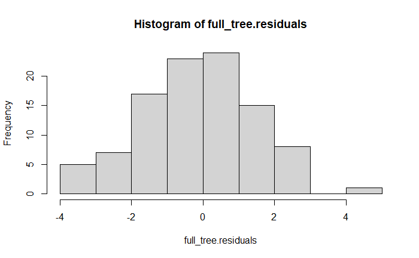

```r
full_tree.residuals = cardata.test$Sales -p1
hist(full_tree.residuals)
```

```r
mean(full_tree.residuals)
```

```
[1] -0.137423
```

```r
cor(cardata.test$Sales ,p1)
```

```
[1] 0.9179315
```

## 3.3 Pruning the large tree

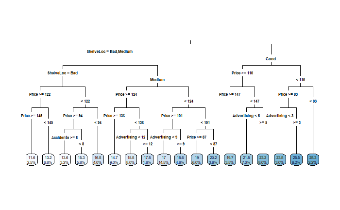

```r
#Create function that finds the best split such that the x error is within 1 standard deviation of the best tree  (with smallest x error term)
cp.select <- function(big.tree) {
  min.x <- which.min(big.tree$cptable[, 4]) #column 4 is xerror
  for(i in 1:nrow(big.tree$cptable)) {
    if(big.tree$cptable[i, 4] < big.tree$cptable[min.x, 4] + big.tree$cptable[min.x, 5]) return(big.tree$cptable[i, 1]) #column 5: xstd, column 1: cp
  }
}


#Pruning the full tree
pruned_tree = prune(rt_model_full, cp.select(rt_model_full))
#jpeg(file="Project_prunedtree.jpeg",width=6, height=4, units="in",res=400)
rpart.plot(pruned_tree, type=3, digits=3, fallen.leaves = T)
```

```r
which.min(rt_model_full$cptable[, 4])
```

```
31
31
```

## 3.4 Prediction

```r
#Creates a new prediction model using the pruned tree
p2=predict(pruned_tree, cardata.test)

#Calculates MAE
MAE(cardata.test$Sales, p2)
```

```
[1] 1.310217
```

```r
#Calculates RMSE
rmse(cardata.test$Sales, p2)
```

```
[1] 1.627433
```

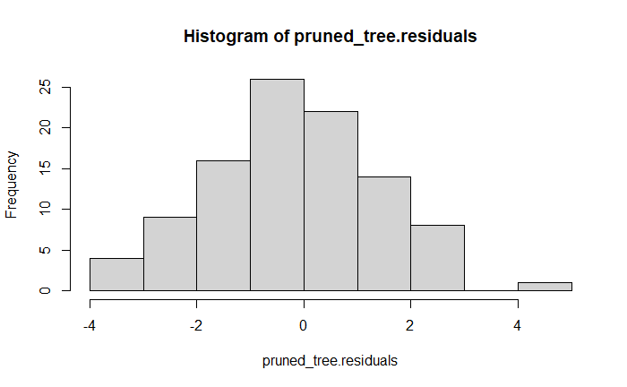

```r
pruned_tree.residuals = cardata.test$Sales -p2
hist(pruned_tree.residuals)
```

```r
mean(pruned_tree.residuals)
```

```
[1] -0.2089084
```

```r
cor(cardata.test$Sales ,p2)
```

```
[1] 0.9207389
```

## 3.5 Create default regression tree with rpart()

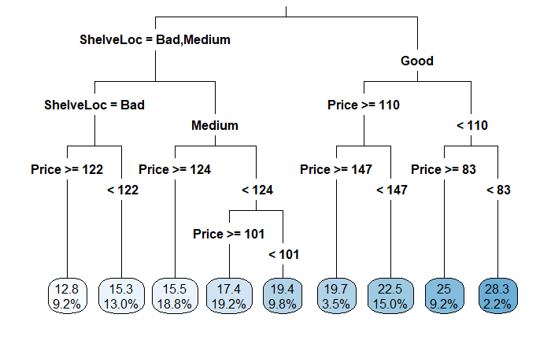

```r
#Creates large regression tree model using testing set and prints the data
rt_model_default = rpart(Sales~., data=cardata.train)
#jpeg(file="Project_default_tree.jpeg",width=6, height=4, units="in",res=400)
rpart.plot(rt_model_default, type=3, digits=3, fallen.leaves = T)
```

```r
#Creates a complexity plot
printcp(rt_model_default)
```

```
Regression tree:
rpart(formula = Sales ~ ., data = cardata.train)

Variables actually used in tree construction:
[1] Price     ShelveLoc

Root node error: 6873.3/400 = 17.183

n= 400

        CP nsplit rel error  xerror     xstd
1 0.635199      0   1.00000 1.00382 0.063680
2 0.069051      1   0.36480 0.36818 0.024713
3 0.054616      2   0.29575 0.32295 0.022491
4 0.044203      3   0.24113 0.29629 0.020742
5 0.020977      4   0.19693 0.23618 0.016856
6 0.015842      5   0.17595 0.21050 0.014564
7 0.013738      6   0.16011 0.19918 0.014264
8 0.011964      7   0.14637 0.19299 0.013947
9 0.010000      8   0.13441 0.18310 0.013062
```

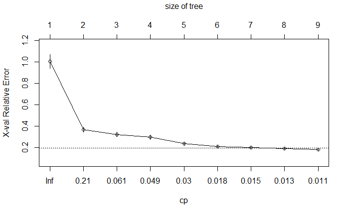

```r
#jpeg(file="Project_cp_vals.jpeg",width=6, height=4, units="in",res=400)
plotcp(rt_model_default)
```

## 3.6 Prediction

```r
#Creates prediction model
p3 = predict(rt_model_default, cardata.test)

#Creates mean absolute error function
MAE = function(actual, predicted){mean(abs(actual-predicted))}
MAE(cardata.test$Sales, p3)
```

```
[1] 1.5148
```

```r
#Calculates root mean square error
rmse(cardata.test$Sales, p3)
```

```
[1] 1.884261
```

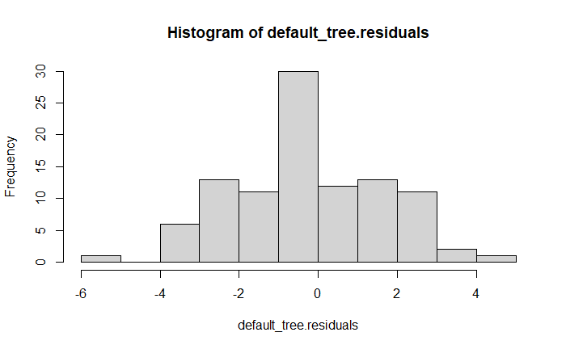

```r
default_tree.residuals = cardata.test$Sales -p3
hist(default_tree.residuals)
```

```r
mean(default_tree.residuals)
```

```
[1] -0.2188267
```

```r
cor(cardata.test$Sales ,p3)
```

```
[1] 0.892502
```